# Project Hackathon and Defense (PHD)

T.Naveen Kumar 2554

# Aim:

To predict credit risk score of Customer based on his past history of payment which as been given by US housing finance company

Since credit risk score play major role for any issueing further loans are benefits from finance company

Credict risk score helps finance company to analysis of customer and take decision on customer request is possible are not also helps increase in customer base

Recommending Systems Help the finance company to check which customers are worth of giving loan bases history of customer

# Problem Statements:

1:Predicting credit risk score of customer with diffent Machine learning models

2:Customer segmentation of data based on payment status

```
Avg.credit risk score on payment status
```

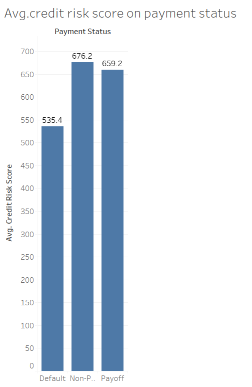

```python
from IPython.display import Image
print("Avg.credit risk score on payment status")
Image(filename='C:\\Users\\Navi\\Desktop\\PHD\\Avg.credit vs spayment ststus.PNG')
```

```
Avg.age vs payment status
```

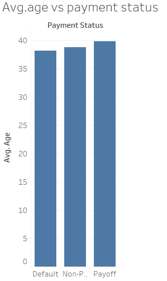

```python
from IPython.display import Image
print("Avg.age vs payment status")
Image(filename='C:\\Users\\Navi\\Desktop\\PHD\\fig4.PNG')
```

```
Avg.salary vs payment status
```

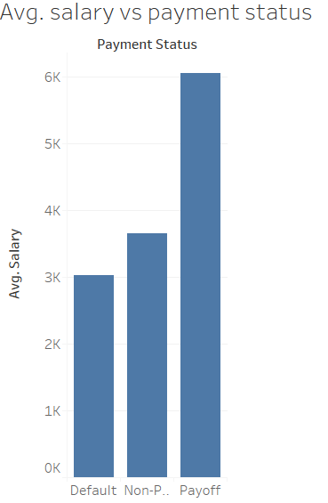

```python
from IPython.display import Image
print("Avg.salary vs payment status")
Image(filename='C:\\Users\\Navi\\Desktop\\PHD\\fig3.PNG')
```

```
change in current outstanding and starting outstanding on bases of paymentstsatus
```

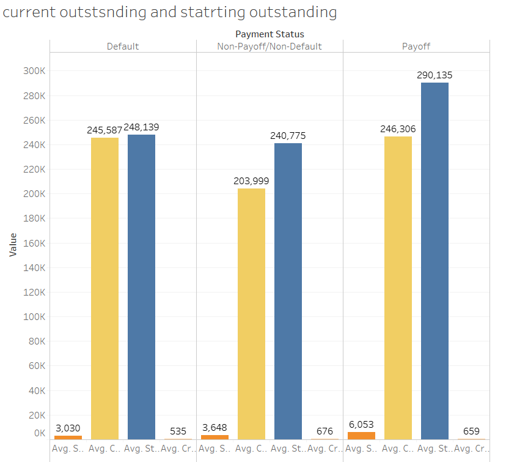

```python
from IPython.display import Image
print("change in current outstanding and starting outstanding on bases of paymentstsatus")
Image(filename='C:\\Users\\Navi\\Desktop\\PHD\\fig2.PNG')
```

As we see from above graph default has very low change in between current and satarting this says that they might wantedly taken loan

```
variation in credit score on payment status aat age of 30-45
```

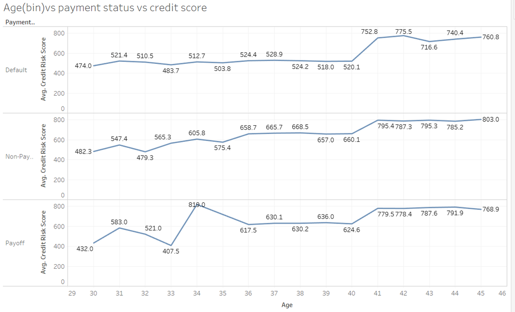

```python
from IPython.display import Image
print("variation in credit score on payment status aat age of 30-45")
Image(filename='C:\\Users\\Navi\\Desktop\\PHD\\fig5.PNG')
```

From above fig we can see that fluction in credit score more on age 30-45

```
current out standing vs starting out standing
```

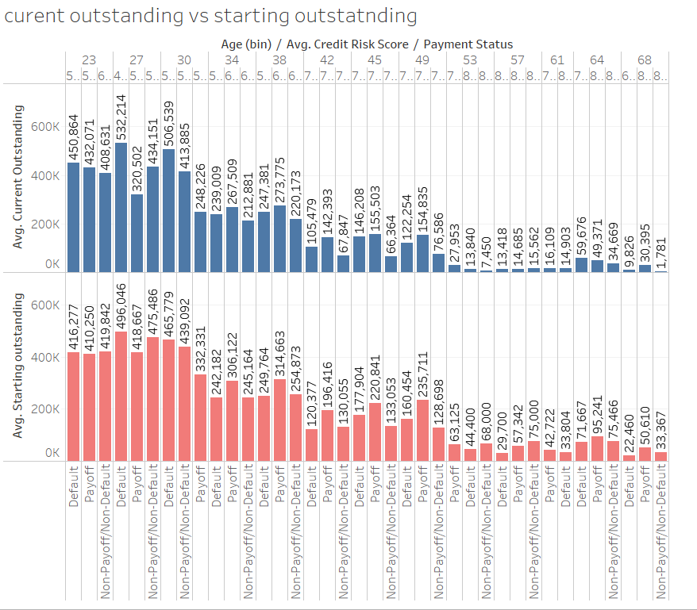

```python
from IPython.display import Image
print("current out standing vs starting out standing ")
Image(filename='C:\\Users\\Navi\\Desktop\\PHD\\fig6.PNG')
```

From above fig we can see decreasing in outsting money as well as default status

```
Curent appraised percent vs present appraised percent
```

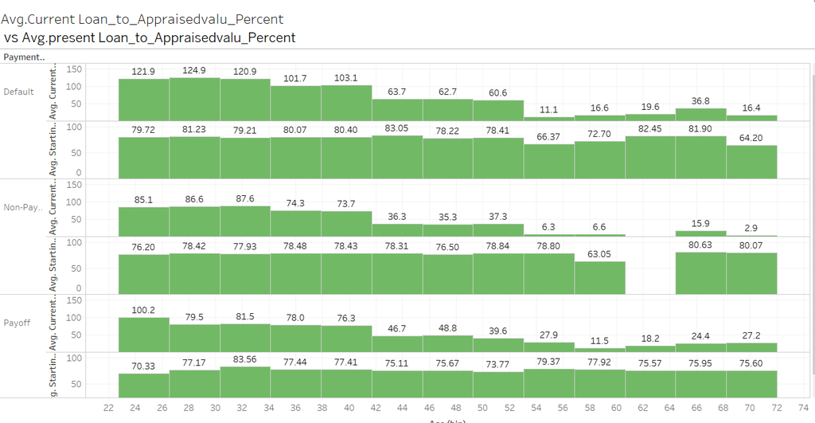

```python
from IPython.display import Image
print("Curent appraised percent vs present appraised percent")
Image(filename='C:\\Users\\Navi\\Desktop\\PHD\\fig7.PNG')
```

We can say from above graph as age increase the percent of appraised value decrased

```
Maturity period vs payment satus
```

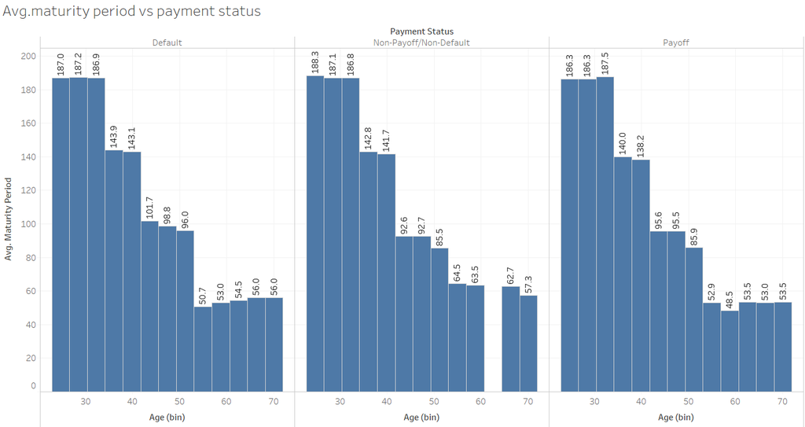

```python
from IPython.display import Image
print("Maturity period vs payment satus ")
Image(filename='C:\\Users\\Navi\\Desktop\\PHD\\fig8.PNG')
```